# Praca domowa 1

Aleksandra Dąbrowska

2 March 2017

# 1 Wczytanie danych, zbudowanie modelu.

Chcemy zbudować model zależności średniego współczynnika GC od rozmiaru genomu.

```r
library(PBImisc)
library(lattice)
library(lmtest)
library(broom)
library(knitr)

dane_geny <- PBImisc::genomes
```

# 2 Analiza graficzna

Sprawdźmy najpierw jak na wykresie wygląda ta zależność.

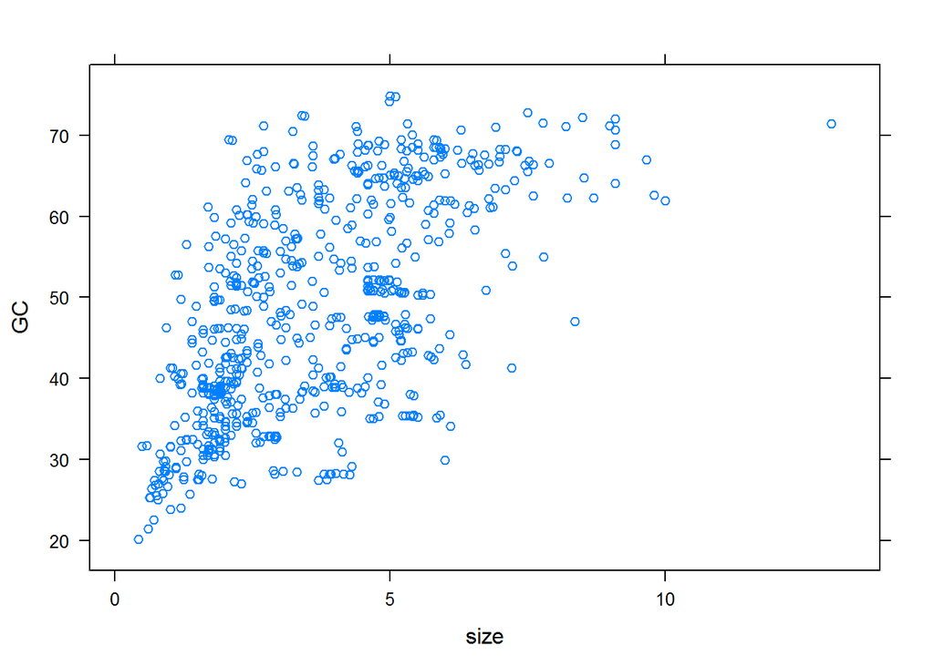

```r
xyplot(GC~size, data=dane_geny)
```

Jak widać zależność między zmiennymi nie jest liniowa. Aby poprawić liniowość zastosuję transformację, polegającą na zlogarytmowaniu obu zmiennych.

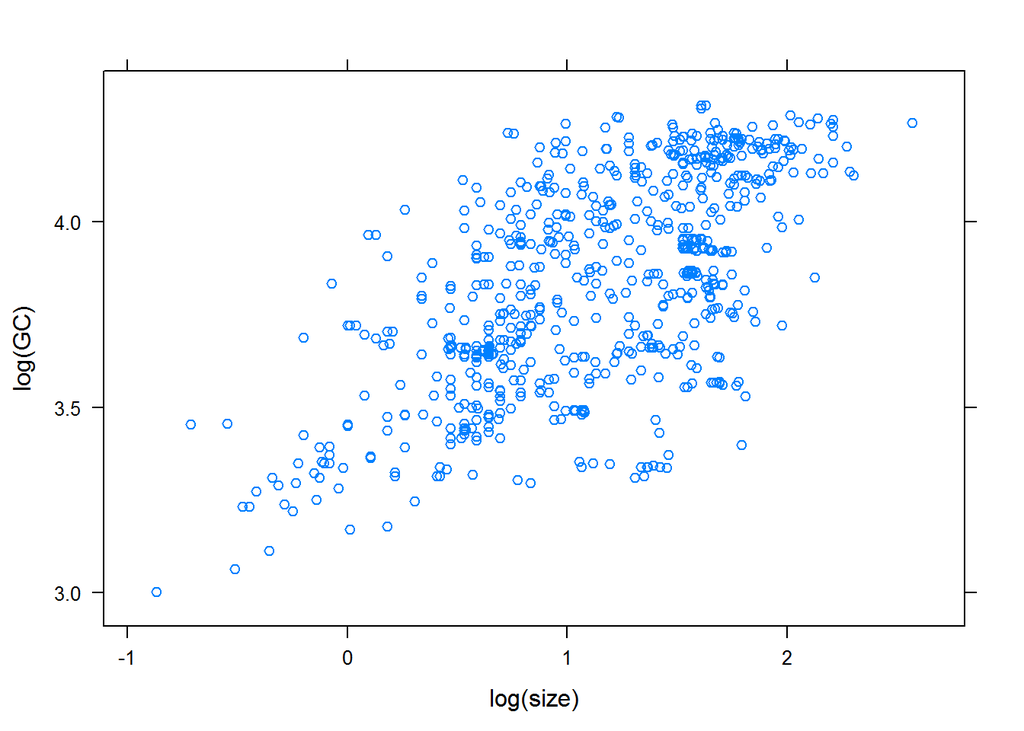

```r
xyplot(log(GC)~log(size), data=dane_geny)
```

# 3 Model liniowy

Dla rozważanej zależności budujemy model liniowy.

```r
model_lm <- lm(log(GC)~log(size), data=dane_geny)
```

```r
kable(tidy(model_lm))
```

| term | estimate | std.error | statistic | p.value |
| --- | --- | --- | --- | --- |
| (Intercept) | 3.4800847 | 0.0175374 | 198.43800 | 0 |
| log(size) | 0.3121397 | 0.0139199 | 22.42391 | 0 |

```r
kable(glance(model_lm))
```

| r.squared | adj.r.squared | sigma | statistic | p.value | df | logLik | AIC | BIC | deviance | df.residual |
| --- | --- | --- | --- | --- | --- | --- | --- | --- | --- | --- |
| 0.4105313 | 0.4097149 | 0.2184307 | 502.8318 | 0 | 2 | 75.10131 | -144.2026 | -130.4482 | 34.44804 | 722 |

Wartość 0 w polach odpowiadających p-value mówi nam, że jest ono mniejsze niż 2.2e-16

# 4 Wykresy diagnostyczne

Przy pomocy funkcji `plot()` przedstawiamy wykresy diagnostyczne dla zbudowanego powyżej modelu.

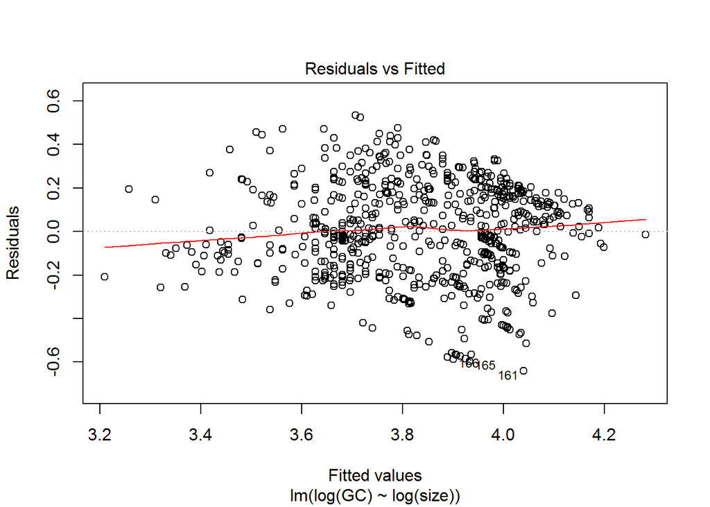

Wartość oczekiwana reszt jest bliska zeru, co może świadczyć o dobrym dopasowaniu modelu.

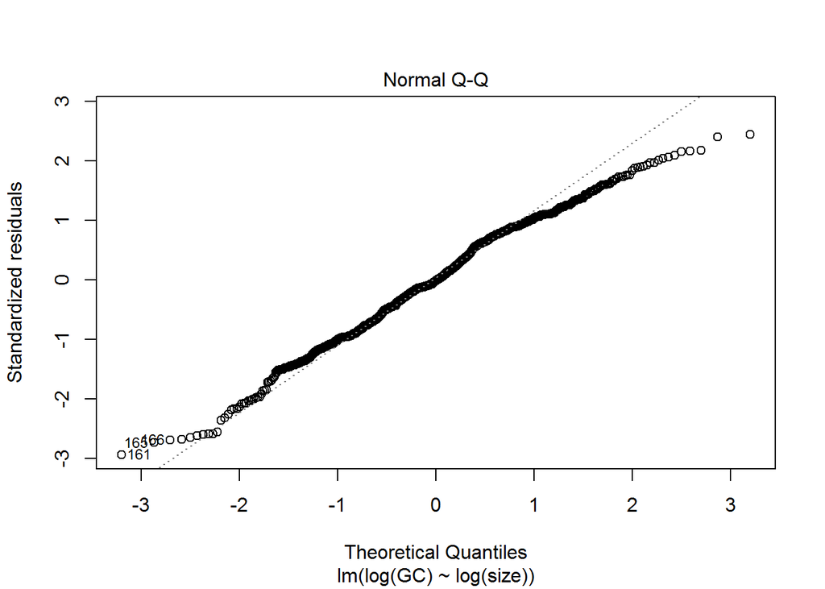

Część punktów nie układa się wzdłuż linii prostej. Może to świadczyć o braku normalności reszt.

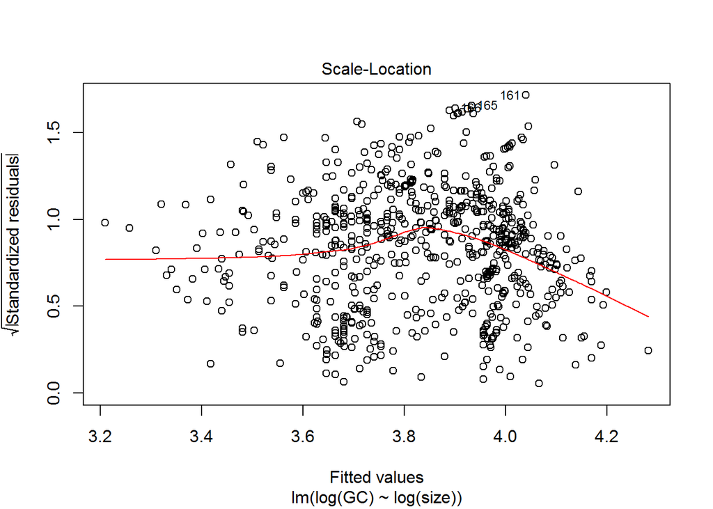

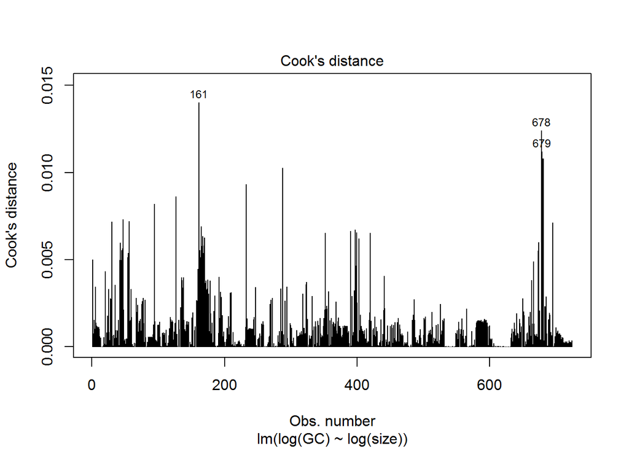

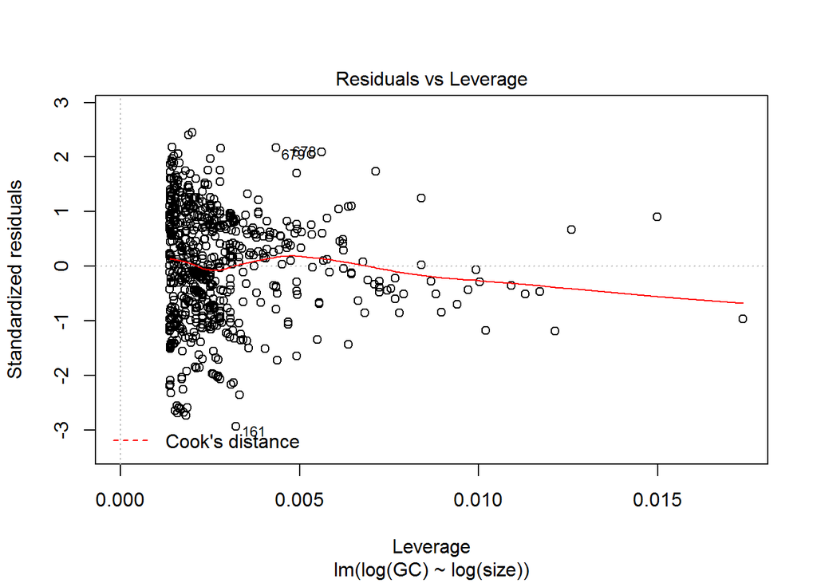

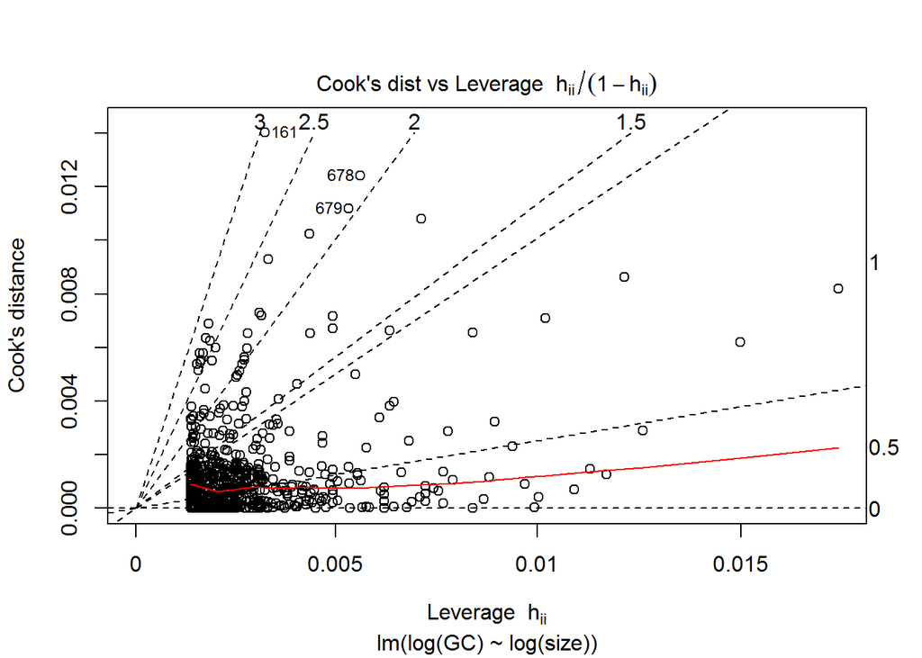

# 5 Reszty i miary wpływu

## 5.1 Reszty

Wyznaczamy reszty standaryzowane i studentyzowane przy pomocy funkcji `rstandard()` i `rstudent()` odpowiednio.

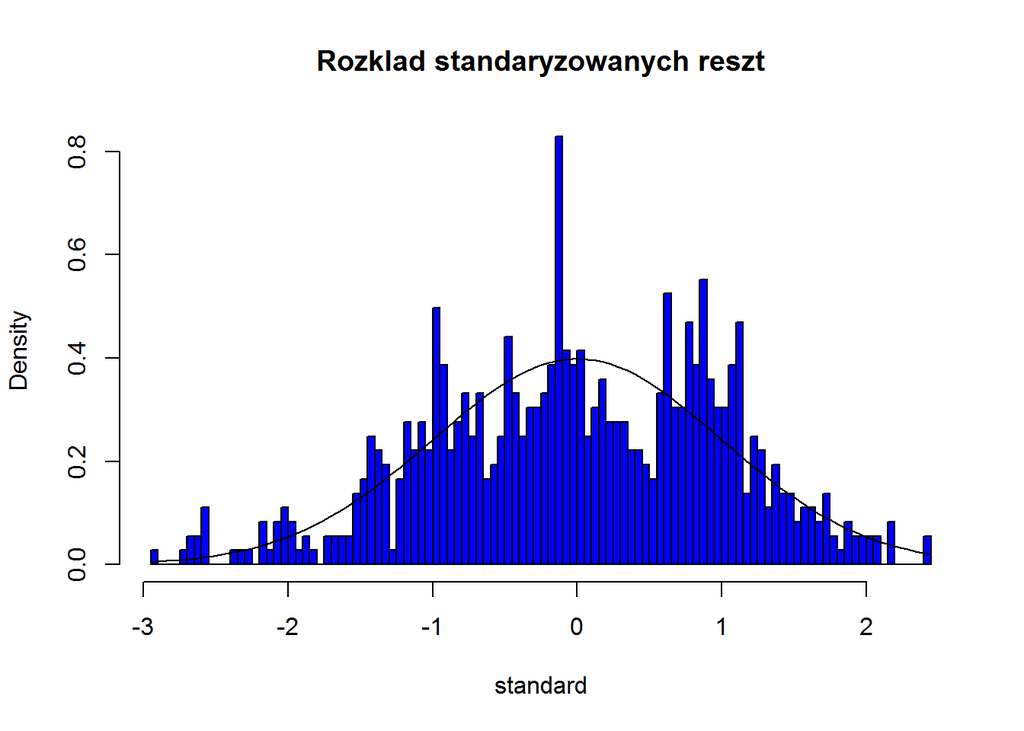

```r
standard <- rstandard(model_lm)
hist(standard, col="blue", probability = TRUE, breaks = 100, main = "Rozkład standaryzowanych reszt")
curve(dnorm(x, mean=mean(standard), sd=sd(standard)), add=TRUE)
```

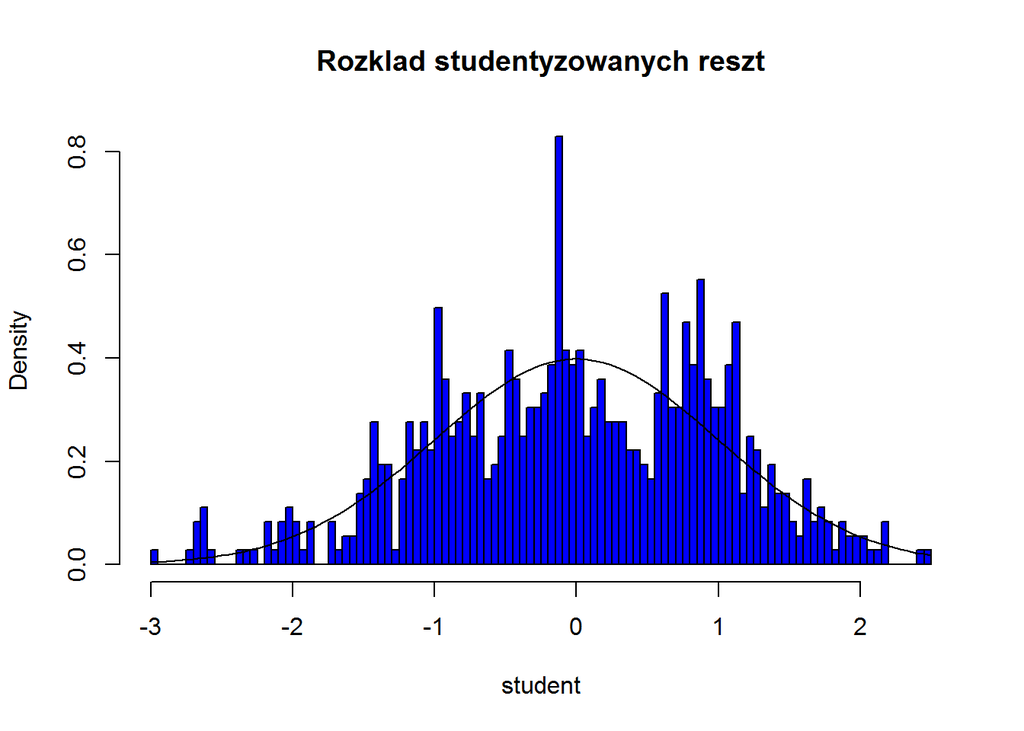

```r
student <- rstudent(model_lm)
hist(student, col="blue", probability = TRUE, breaks = 100, main = "Rozkład studentyzowanych reszt")
curve(dnorm(x, mean=mean(student), sd=sd(student)), add=TRUE)
```

Na histogramy została nałożona krzywa odpowiadająca rozkładowi normalnemu ze średnimi i odchyleniami standardowymi odpowiadającymi danym. Jak widać rozkłady reszt sa różne od normalnego.

## 5.2 Miara wpływu

Wyznaczamy miarę Cook’a wpływu obserwacji.

```r
cook <- cooks.distance(model_lm)
```

Korzystając z wykresów diagnostycznych możemy określić nietypowe obserwacje (o wartościach wiekszych niz 1).

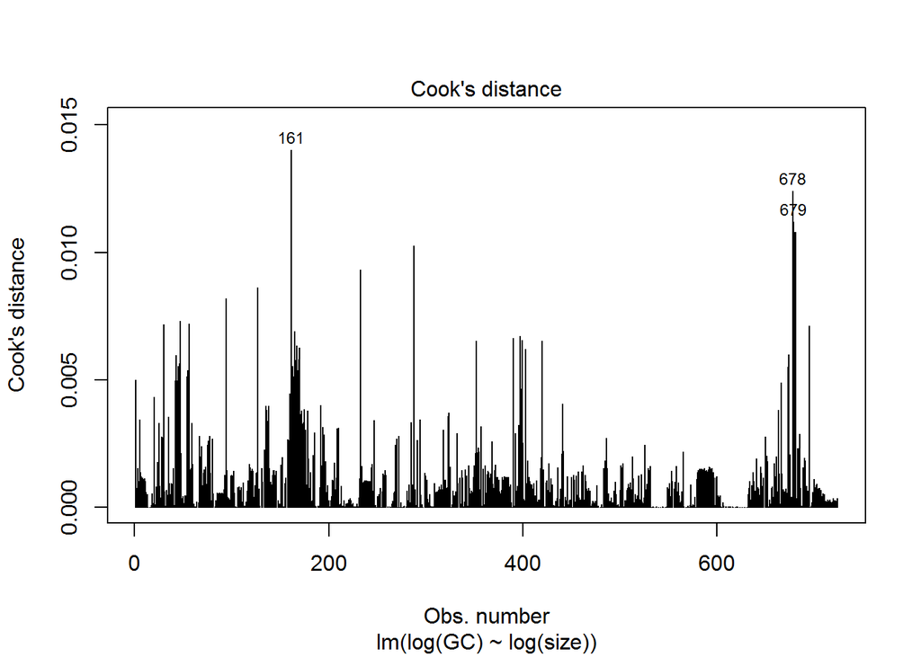

```r
plot(model_lm, which=4)
```

# 6 Testy diagnostyczne dla modelu

## 6.1 Testy jednorodności wariancji

### 6.1.1 Breuscha-Pagana

| statistic | p.value | parameter | method |
| --- | --- | --- | --- |
| 0.1794621 | 0.6718359 | 1 | studentized Breusch-Pagan test |

Nie odrzucamy hipotezy zerowej mowiącej o braku zależności między wariancją reszt a predyktorami (duże p-value).

### 6.1.2 Goldfelda-Quandta

| df1 | df2 | statistic | p.value | method | alternative |
| --- | --- | --- | --- | --- | --- |
| 360 | 360 | 1.070193 | 0.2600884 | Goldfeld-Quandt test | variance increases from segment 1 to 2 |

Nie mamy podstaw do odrzucenia hipotezy zerowej (duże p-value), która mówi, że wariancje reszt dla małej wielkości zmiennej size nie różnią się od wariancji dla większej wartości zmiennej size..

### 6.1.3 Harrisona-McCabe’a

| statistic | p.value | method |
| --- | --- | --- |
| 0.4835529 | 0.251 | Harrison-McCabe test |

Test Harrisona-McCabe’a sprawdza tę samą hipotezę co test Goldfelda-Quandta. Nie odrzucamy hipotezy H0 (duże p-value).

## 6.2 Testy niezależności reszt

### 6.2.1 Durbina-Watsona

| statistic | p.value | method | alternative |
| --- | --- | --- | --- |
| 1.779475 | 0.0013136 | Durbin-Watson test | true autocorrelation is greater than 0 |

Odrzucamy hipotezę zerową na rzecz alternatywnej mowiącej o istnieniu autokorelacji między resztami, które posortowaliśmy ze względu na zmienną `size` (małe p-value).

### 6.2.2 Breuscha-Godfrey’a

| statistic | p.value | parameter | method |
| --- | --- | --- | --- |
| 8.701394 | 0.0031797 | 1 | Breusch-Godfrey test for serial correlation of order up to 1 |

Odrzucamy hipotezę zerową (małe p-value).Zatem istnieją korelacje rzędu => 1.

## 6.3 Testy liniowości modelu

### 6.3.1 Harvey’a-Colliera

| statistic | p.value | parameter | method |
| --- | --- | --- | --- |
| 0.8548366 | 0.3929255 | 721 | Harvey-Collier test |

Nie mamy podstaw do odrzucenia hipotezy zerowej mowiącej o liniowości modelu (duże p-value).

### 6.3.2 Rainbow

| df1 | df2 | statistic | p.value | method |
| --- | --- | --- | --- | --- |
| 362 | 360 | 0.664702 | 0.9999444 | Rainbow test |

Nie mamy podstaw do odrzucenia hipotezy zerowej, która mówi, że reszty wyznaczone na podzbiorze obserwacji nie różnią się od reszt w całym modelu (duże p-value).

### 6.3.3 Ramsey’a RESET

| df1 | df2 | statistic | p.value | method |
| --- | --- | --- | --- | --- |
| 2 | 720 | 1.356395 | 0.2582452 | RESET test |

Nie ma podstaw do odrzucenia hipotezy zerowej (duże p-value).

## 6.4 Test normalności reszt

### 6.4.1 Shapiro-Wilka

| statistic | p.value | method |
| --- | --- | --- |
| 0.99057 | 0.0001371 | Shapiro-Wilk normality test |

Odrzucamy hipotezę o normalności reszt modelu.

# 7 Podsumowanie

Jak wynika z testów wygenerowanych na modelu zależności logarytmu GC od logarytmu rozmiaru nie mamy podstaw do odrzucenia hipotez na temat jednorodności wariancji ani liniowości tego modelu. Jednak odrzucamy hipotezę na temat niezależności reszt oraz tego, że mają one rozkład normalny.